# AIPND_image_classifier_project

## AI Programming with Python Nanodegree: Image Classifier Project

- Do not make changes to the first 2 code cells, they are being used for setting up the `flowers` dataset and `cat_to_name.json`. Start writing code from third code cell onwards.
- To use this notebook: `File > Save a copy in Drive`

### Code Explanation:

- **Setting Up Flower Dataset:**
  - `data_dir = './flowers'`: Defines the directory path for the flower dataset.
  - `FLOWERS_DIR = Path(data_dir)`: Uses `Path` from `pathlib` for handling PosixPath.
- **Downloading and Extracting Dataset:**
  - `if not FLOWERS_DIR.is_dir()`: Checks if the dataset directory exists.
    - `FLOWERS_DIR.mkdir(parents=True, exist_ok=True)`: Creates the directory if not present.
  - `TARBALL = FLOWERS_DIR / "flower_data.tar.gz"`: Defines the tarball path.
  - Downloads and extracts the dataset if not already present:
    - `request = requests.get(...)`: Downloads the 'flower_data.tar.gz' file.
    - `with open(TARBALL, "wb") as file_ref`: Writes the downloaded content to the tarball.
    - `with tarfile.open(TARBALL, "r") as tar_ref`: Extracts the tarball contents to the dataset directory.
- **Cleaning Up:**
  - `os.remove(TARBALL)`: Deletes the downloaded tarball to save space.
- **Status Messages:**
  - Prints informative messages about the directory creation, download, extraction, and cleanup.

```python
# imports
import os
import requests
from pathlib import Path
import tarfile

# defining dataset directory
data_dir = './flowers'

# using pathlib.Path for handling PosixPath
FLOWERS_DIR = Path(data_dir)

# downloading and setting up data if not already present
if not FLOWERS_DIR.is_dir():
    # creating directory
    FLOWERS_DIR.mkdir(parents=True, exist_ok=True)
    print(f"[INFO] Directory created: ./{FLOWERS_DIR}")

    print() # for readability

    # tarball path
    TARBALL = FLOWERS_DIR / "flower_data.tar.gz"

    # downloading and writing the tarball to './flowers' directory
    print(f"[INFO] Downloading the file 'flower_data.tar.gz' to ./{FLOWERS_DIR}")
    request = requests.get('https://s3.amazonaws.com/content.udacity-data.com/nd089/flower_data.tar.gz')
    with open(TARBALL, "wb") as file_ref:
        file_ref.write(request.content)
        print(f"[INFO] 'flower_data.tar.gz' saved to ./{FLOWERS_DIR}")

    print() # for readability

    # extracting the downloaded tarball
    print(f"[INFO] Extracting the downloaded tarball to ./{FLOWERS_DIR}")
    with tarfile.open(TARBALL, "r") as tar_ref:
        tar_ref.extractall(FLOWERS_DIR)
        print(f"[INFO] 'flower_data.tar.gz' extracted successfully to ./{FLOWERS_DIR}")

    print() # for readability

    # using os.remove to delete the downloaded tarball
    print("[INFO] Deleting the tarball to save space.")
    os.remove(TARBALL)
else:
    print(f"[INFO] Dataset already setup at ./{FLOWERS_DIR}")
```

```
[INFO] Dataset already setup at ./flowers
```

### Code Explanation:

- **Creating a JSON File for Flower Categories:**
  - `data`: Defines a dictionary containing numerical keys and corresponding flower names.
  - `with open('cat_to_name.json', 'w') as file`: Opens the file 'cat_to_name.json' for writing.
  - `json.dump(data, file)`: Writes the dictionary data to the JSON file.
- **Interpreting the Output:**
  - The code creates a JSON file named 'cat_to_name.json' that serves as a mapping between numerical keys and flower names. This mapping can be useful for associating numerical labels with human-readable names in machine learning tasks.

```python
import json

data = {
    "21": "fire lily", "3": "canterbury bells", "45": "bolero deep blue", "1": "pink primrose", "34": "mexican aster",
    "27": "prince of wales feathers", "7": "moon orchid", "16": "globe-flower", "25": "grape hyacinth", "26": "corn poppy",
    "79": "toad lily", "39": "siam tulip", "24": "red ginger", "67": "spring crocus", "35": "alpine sea holly",
    "32": "garden phlox", "10": "globe thistle", "6": "tiger lily", "93": "ball moss", "33": "love in the mist",
    "9": "monkshood", "102": "blackberry lily", "14": "spear thistle", "19": "balloon flower", "100": "blanket flower",
    "13": "king protea", "49": "oxeye daisy", "15": "yellow iris", "61": "cautleya spicata", "31": "carnation",
    "64": "silverbush", "68": "bearded iris", "63": "black-eyed susan", "69": "windflower", "62": "japanese anemone",
    "20": "giant white arum lily", "38": "great masterwort", "4": "sweet pea", "86": "tree mallow",
    "101": "trumpet creeper", "42": "daffodil", "22": "pincushion flower", "2": "hard-leaved pocket orchid",
    "54": "sunflower", "66": "osteospermum", "70": "tree poppy", "85": "desert-rose", "99": "bromelia", "87": "magnolia",
    "5": "english marigold", "92": "bee balm", "28": "stemless gentian", "97": "mallow", "57": "gaura",
    "40": "lenten rose", "47": "marigold", "59": "orange dahlia", "48": "buttercup", "55": "pelargonium",
    "36": "ruby-lipped cattleya", "91": "hippeastrum", "29": "artichoke", "71": "gazania", "90": "canna lily",
    "18": "peruvian lily", "98": "mexican petunia", "8": "bird of paradise", "30": "sweet william",
    "17": "purple coneflower", "52": "wild pansy", "84": "columbine", "12": "colt's foot", "11": "snapdragon",
    "96": "camellia", "23": "fritillary", "50": "common dandelion", "44": "poinsettia", "53": "primula",
    "72": "azalea", "65": "californian poppy", "80": "anthurium", "76": "morning glory", "37": "cape flower",
    "56": "bishop of llandaff", "60": "pink-yellow dahlia", "82": "clematis", "58": "geranium", "75": "thorn apple",
    "41": "barbeton daisy", "95": "bougainvillea", "43": "sword lily", "83": "hibiscus", "78": "lotus lotus",
    "88": "cyclamen", "94": "foxglove", "81": "frangipani", "74": "rose", "89": "watercress", "73": "water lily",
    "46": "wallflower", "77": "passion flower", "51": "petunia"
}

with open('cat_to_name.json', 'w') as file:
    json.dump(data, file)
```

```python
# Imports here
import torch
import torch.nn as nn
import torchvision
import matplotlib.pyplot as plt
import numpy as np
from torchvision import transforms
from PIL import Image
from torch.utils.data import DataLoader
import json
from typing import Tuple, Callable, Union, Any

try:
    from torchinfo import summary
    from tqdm.autonotebook import tqdm
    from torchmetrics.classification import MulticlassAccuracy, MulticlassF1Score
except:
        # installing torchinfo and then importing
    print("[INFO] Installing torchinfo for network architecture explanation.")
    %pip install torchinfo
    from torchinfo import summary

    # for readability
    print()

    # installing tqdm and then importing
    print("[INFO] Installing tqdm for progress bar.")
    %pip install tqdm
    from tqdm.autonotebook import tqdm

    # for readability
    print()

    # installing torchmetrics and importing MulticlassAccuracy and MulticlassF1Score
    print("[INFO] Installing torchmetrics for computing metrics for training/eval runs.")
    %pip install torchmetrics
    from torchmetrics.classification import MulticlassAccuracy, MulticlassF1Score
```

```python
# selecting hyperparameters

BATCH_SIZE = 32
LEARNING_RATE = 1e-3
EPOCHS = 15
HIDDEN_LAYER1 = 512
HIDDEN_LAYER2 = 256
```

```python
#train_dir = data_dir + '/train'
#valid_dir = data_dir + '/valid'
#test_dir = data_dir + '/test'
```

```python
def manual_seed(random_seed: int= 42)-> None:
    """For maintaining reproducibilit of a notebook cell"""
    #for non_cuda device
    torch.manual_seed(random_seed)
    if torch.cuda.is_available():
        torch.cuda.manual_seed(random_seed)

#Set device to gpu or cpu
if torch.cuda.is_available():
    device= torch.device("cuda")
    print("cuda")
else:
    device= torch.device("cpu")

#Clear up cache if using gpu
if str(device)=="cuda":
    torch.cuda.empty_cache()
```

```
cuda
```

```python
mobilenet_weights= torchvision.models.MobileNet_V3_Large_Weights.DEFAULT

mobilenet_transforms= mobilenet_weights.transforms()

print(mobilenet_transforms)

# Define the model
model= torchvision.models.mobilenet_v3_large(weights= mobilenet_weights)
```

```
ImageClassification(
    crop_size=[224]
    resize_size=[232]
    mean=[0.485, 0.456, 0.406]
    std=[0.229, 0.224, 0.225]
    interpolation=InterpolationMode.BILINEAR
)
```

```python
# using torchinfo to inspect the network

summary(model,
        input_size=(1,3,224,224),
        col_names=("input_size",
                   "output_size",
                   "num_params",
                   "kernel_size",
                   "mult_adds",
                   "trainable"),
        col_width=20,
        row_settings=("var_names",))
```

```
====================================================================================================================================================================================
Layer (type (var_name))                                      Input Shape          Output Shape         Param #              Kernel Shape         Mult-Adds            Trainable
====================================================================================================================================================================================
MobileNetV3 (MobileNetV3)                                    [1, 3, 224, 224]     [1, 1000]            --                   --                   --                   True
├─Sequential (features)                                      [1, 3, 224, 224]     [1, 960, 7, 7]       --                   --                   --                   True
│    └─Conv2dNormActivation (0)                              [1, 3, 224, 224]     [1, 16, 112, 112]    --                   --                   --                   True
│    │    └─Conv2d (0)                                       [1, 3, 224, 224]     [1, 16, 112, 112]    432                  [3, 3]               5,419,008            True
│    │    └─BatchNorm2d (1)                                  [1, 16, 112, 112]    [1, 16, 112, 112]    32                   --                   32                   True
│    │    └─Hardswish (2)                                    [1, 16, 112, 112]    [1, 16, 112, 112]    --                   --                   --                   --
│    └─InvertedResidual (1)                                  [1, 16, 112, 112]    [1, 16, 112, 112]    --                   --                   --                   True
│    │    └─Sequential (block)                               [1, 16, 112, 112]    [1, 16, 112, 112]    464                  --                   5,017,664            True
│    └─InvertedResidual (2)                                  [1, 16, 112, 112]    [1, 24, 56, 56]      --                   --                   --                   True
│    │    └─Sequential (block)                               [1, 16, 112, 112]    [1, 24, 56, 56]      3,440                --                   19,468,592           True
│    └─InvertedResidual (3)                                  [1, 24, 56, 56]      [1, 24, 56, 56]      --                   --                   --                   True
│    │    └─Sequential (block)                               [1, 24, 56, 56]      [1, 24, 56, 56]      4,440                --                   12,870,480           True
│    └─InvertedResidual (4)                                  [1, 24, 56, 56]      [1, 40, 28, 28]      --                   --                   --                   True
│    │    └─Sequential (block)                               [1, 24, 56, 56]      [1, 40, 28, 28]      10,328               --                   9,092,048            True
│    └─InvertedResidual (5)                                  [1, 40, 28, 28]      [1, 40, 28, 28]      --                   --                   --                   True
│    │    └─Sequential (block)                               [1, 40, 28, 28]      [1, 40, 28, 28]      20,992               --                   9,886,792            True
│    └─InvertedResidual (6)                                  [1, 40, 28, 28]      [1, 40, 28, 28]      --                   --                   --                   True
│    │    └─Sequential (block)                               [1, 40, 28, 28]      [1, 40, 28, 28]      20,992               --                   9,886,792            True
│    └─InvertedResidual (7)                                  [1, 40, 28, 28]      [1, 80, 14, 14]      --                   --                   --                   True
│    │    └─Sequential (block)                               [1, 40, 28, 28]      [1, 80, 14, 14]      32,080               --                   11,714,080           True
│    └─InvertedResidual (8)                                  [1, 80, 14, 14]      [1, 80, 14, 14]      --                   --                   --                   True
│    │    └─Sequential (block)                               [1, 80, 14, 14]      [1, 80, 14, 14]      34,760               --                   6,625,760            True
│    └─InvertedResidual (9)                                  [1, 80, 14, 14]      [1, 80, 14, 14]      --                   --                   --                   True
```

[output cut: 34 more lines]

```python
# TODO: Define your transforms for the training, validation, and testing sets
train_transforms = transforms.Compose([
    transforms.Resize((224,224),interpolation= transforms.InterpolationMode.BILINEAR),
    transforms.TrivialAugmentWide(interpolation = transforms.InterpolationMode.BILINEAR),
    transforms.CenterCrop(size= (224,224)),
    transforms.ToTensor(),
    transforms.Normalize(mean= [0.485, 0.456, 0.406],
                        std=[0.229, 0.224, 0.225])
])
```

```python
# TODO: Load the datasets with ImageFolder
train_dataset = torchvision.datasets.ImageFolder(root= str(FLOWERS_DIR/Path("train")), transform= train_transforms)
valid_dataset = torchvision.datasets.ImageFolder(root= str(FLOWERS_DIR/Path("valid")), transform= mobilenet_transforms )
test_dataset = torchvision.datasets.ImageFolder(root= str(FLOWERS_DIR/Path("test")), transform= mobilenet_transforms)

# TODO: Using the image datasets and the trainforms, define the dataloaders
train_dataloaders = DataLoader(train_dataset, batch_size= 32, shuffle= True)
valid_dataloaders = DataLoader(valid_dataset, batch_size= 32, shuffle= False)
test_dataloaders = DataLoader(test_dataset, batch_size= 32, shuffle= False)

#image_pth, labels= zip(*test_datasets.samples)
#print(test_datasets)
#print(image_pth, labels)


#extracting number of classes and class_to_idx mapping
CLASSES= train_dataset.classes
NUM_CLASSES= len(CLASSES)
CLASS_TO_IDX= train_dataset.class_to_idx
print(CLASS_TO_IDX)
```

```
{'1': 0, '10': 1, '100': 2, '101': 3, '102': 4, '11': 5, '12': 6, '13': 7, '14': 8, '15': 9, '16': 10, '17': 11, '18': 12, '19': 13, '2': 14, '20': 15, '21': 16, '22': 17, '23': 18, '24': 19, '25': 20, '26': 21, '27': 22, '28': 23, '29': 24, '3': 25, '30': 26, '31': 27, '32': 28, '33': 29, '34': 30,…
```

```python
manual_seed()

for params in model.parameters():
    params.require_grad= False


# Define the model
model= torchvision.models.mobilenet_v3_large(weights= mobilenet_weights)
model.classifier= nn.Sequential(nn.Linear(960, HIDDEN_LAYER1),
                        nn.ReLU(),
                        nn.Linear(HIDDEN_LAYER1, HIDDEN_LAYER2),
                        nn.ReLU(),
                        nn.Linear(HIDDEN_LAYER2, NUM_CLASSES)
                       )
model
```

```
MobileNetV3(
  (features): Sequential(
    (0): Conv2dNormActivation(
      (0): Conv2d(3, 16, kernel_size=(3, 3), stride=(2, 2), padding=(1, 1), bias=False)
      (1): BatchNorm2d(16, eps=0.001, momentum=0.01, affine=True, track_running_stats=True)
      (2): Hardswish()
    )
    (1): InvertedResidual(
      (block): Sequential(
        (0): Conv2dNormActivation(
          (0): Conv2d(16, 16, kernel_size=(3, 3), stride=(1, 1), padding=(1, 1), groups=16, bias=False)
          (1): BatchNorm2d(16, eps=0.001, momentum=0.01, affine=True, track_running_stats=True)
          (2): ReLU(inplace=True)
        )
        (1): Conv2dNormActivation(
          (0): Conv2d(16, 16, kernel_size=(1, 1), stride=(1, 1), bias=False)
          (1): BatchNorm2d(16, eps=0.001, momentum=0.01, affine=True, track_running_stats=True)
        )
      )
    )
    (2): InvertedResidual(
      (block): Sequential(
        (0): Conv2dNormActivation(
          (0): Conv2d(16, 64, kernel_size=(1, 1), stride=(1, 1), bias=False)
          (1): BatchNorm2d(64, eps=0.001, momentum=0.01, affine=True, track_running_stats=True)
          (2): ReLU(inplace=True)
        )
        (1): Conv2dNormActivation(
          (0): Conv2d(64, 64, kernel_size=(3, 3), stride=(2, 2), padding=(1, 1), groups=64, bias=False)
          (1): BatchNorm2d(64, eps=0.001, momentum=0.01, affine=True, track_running_stats=True)
          (2): ReLU(inplace=True)
        )
        (2): Conv2dNormActivation(
          (0): Conv2d(64, 24, kernel_size=(1, 1), stride=(1, 1), bias=False)
          (1): BatchNorm2d(24, eps=0.001, momentum=0.01, affine=True, track_running_stats=True)
        )
      )
    )
    (3): InvertedResidual(
      (block): Sequential(
```

[output cut: 288 more lines]

```
    (16): Conv2dNormActivation(
      (0): Conv2d(160, 960, kernel_size=(1, 1), stride=(1, 1), bias=False)
      (1): BatchNorm2d(960, eps=0.001, momentum=0.01, affine=True, track_running_stats=True)
      (2): Hardswish()
    )
  )
  (avgpool): AdaptiveAvgPool2d(output_size=1)
  (classifier): Sequential(
    (0): Linear(in_features=960, out_features=512, bias=True)
    (1): ReLU()
    (2): Linear(in_features=512, out_features=256, bias=True)
    (3): ReLU()
    (4): Linear(in_features=256, out_features=102, bias=True)
  )
)
```

```python
summary(model,
        input_size=(1,3,224,224),
        col_names=("input_size",
                   "output_size",
                   "num_params",
                   "kernel_size",
                   "mult_adds",
                   "trainable"),
        col_width=20,
        row_settings=("var_names",))
```

```
====================================================================================================================================================================================
Layer (type (var_name))                                      Input Shape          Output Shape         Param #              Kernel Shape         Mult-Adds            Trainable
====================================================================================================================================================================================
MobileNetV3 (MobileNetV3)                                    [1, 3, 224, 224]     [1, 102]             --                   --                   --                   True
├─Sequential (features)                                      [1, 3, 224, 224]     [1, 960, 7, 7]       --                   --                   --                   True
│    └─Conv2dNormActivation (0)                              [1, 3, 224, 224]     [1, 16, 112, 112]    --                   --                   --                   True
│    │    └─Conv2d (0)                                       [1, 3, 224, 224]     [1, 16, 112, 112]    432                  [3, 3]               5,419,008            True
│    │    └─BatchNorm2d (1)                                  [1, 16, 112, 112]    [1, 16, 112, 112]    32                   --                   32                   True
│    │    └─Hardswish (2)                                    [1, 16, 112, 112]    [1, 16, 112, 112]    --                   --                   --                   --
│    └─InvertedResidual (1)                                  [1, 16, 112, 112]    [1, 16, 112, 112]    --                   --                   --                   True
│    │    └─Sequential (block)                               [1, 16, 112, 112]    [1, 16, 112, 112]    464                  --                   5,017,664            True
│    └─InvertedResidual (2)                                  [1, 16, 112, 112]    [1, 24, 56, 56]      --                   --                   --                   True
│    │    └─Sequential (block)                               [1, 16, 112, 112]    [1, 24, 56, 56]      3,440                --                   19,468,592           True
│    └─InvertedResidual (3)                                  [1, 24, 56, 56]      [1, 24, 56, 56]      --                   --                   --                   True
│    │    └─Sequential (block)                               [1, 24, 56, 56]      [1, 24, 56, 56]      4,440                --                   12,870,480           True
│    └─InvertedResidual (4)                                  [1, 24, 56, 56]      [1, 40, 28, 28]      --                   --                   --                   True
│    │    └─Sequential (block)                               [1, 24, 56, 56]      [1, 40, 28, 28]      10,328               --                   9,092,048            True
│    └─InvertedResidual (5)                                  [1, 40, 28, 28]      [1, 40, 28, 28]      --                   --                   --                   True
│    │    └─Sequential (block)                               [1, 40, 28, 28]      [1, 40, 28, 28]      20,992               --                   9,886,792            True
│    └─InvertedResidual (6)                                  [1, 40, 28, 28]      [1, 40, 28, 28]      --                   --                   --                   True
│    │    └─Sequential (block)                               [1, 40, 28, 28]      [1, 40, 28, 28]      20,992               --                   9,886,792            True
│    └─InvertedResidual (7)                                  [1, 40, 28, 28]      [1, 80, 14, 14]      --                   --                   --                   True
│    │    └─Sequential (block)                               [1, 40, 28, 28]      [1, 80, 14, 14]      32,080               --                   11,714,080           True
│    └─InvertedResidual (8)                                  [1, 80, 14, 14]      [1, 80, 14, 14]      --                   --                   --                   True
│    │    └─Sequential (block)                               [1, 80, 14, 14]      [1, 80, 14, 14]      34,760               --                   6,625,760            True
│    └─InvertedResidual (9)                                  [1, 80, 14, 14]      [1, 80, 14, 14]      --                   --                   --                   True
```

[output cut: 35 more lines]

```python
def training_step(model: nn.Module,
                 train_dataloader: torch.utils.data.DataLoader,
                 optimizer: torch.optim.Optimizer,
                  criterion: nn.Module,
                 training_accuracy: MulticlassAccuracy,
                 training_f1: MulticlassF1Score,
                 epoch_num: int,
                 device: torch.device = device) -> Tuple[torch.Tensor, torch.Tensor, torch.Tensor]:

    # settting model tp train mode
    model.train()

    # restting the torchmetrics metrics
    training_accuracy.reset()
    training_f1.reset()

    # varible for calculting the epoch loss
    epoch_loss= 0

    #Use tqdm for progress bar
    with tqdm(enumerate(train_dataloaders, start= 1), total= len(train_dataloaders), unit= "train-batch") as tepoch:
        # iterating over the data batches
        for batch_idx, (features, labels) in tepoch:
            # setting description for tqdm progress bar
            tepoch.set_description(f"Epoch: {epoch_num+1}  Phase - Training")

            # moving the batches to device
            features, labels = features.to(device), labels.to(device).type(torch.long)

            # doing forward propagation
            logits= model(features)

            #calculating loss
            loss= criterion(logits, labels)

            #Zero out accumulated gradients from the previous iteration
            optimizer.zero_grad()

            #doing backpropagation
            loss.backward()

            # taking an optimization step using the gradients computed above
            optimizer.step()

            with torch.no_grad():
                avg_loss_sample= loss/len(labels)
                batch_acc= training_accuracy.forward(logits, labels)
                batch_f1= training_f1.forward(logits, labels)

            # accumulating in epoch loss
            epoch_loss+= avg_loss_sample

            # setting postfix for progress bar
            tepoch.set_postfix(batch_f1_score= batch_f1.item(),  batch_accuracy=f"{batch_acc.item()*100:.2f}%", loss_per_sample=avg_loss_sample.item())

    epoch_loss/= len(train_dataloaders)

    print()

     # printing epoch statistics
    print(f"[INFO] Epoch: {epoch_num+1} | loss: {epoch_loss.item():.3f} | training acc: {training_accuracy.compute().item()*100:.2f}% | training f1-score: {training_f1.compute().item():.2f}")

    # returning loss, acc and f1
    return epoch_loss, training_accuracy.compute(), training_f1.compute()
```

```python
def testing_step(model: nn.Module,
                 test_dataloader: torch.utils.data.DataLoader,
                 criterion: nn.Module, # I changed optimizer to criterion
                 test_accuracy: MulticlassAccuracy,
                 test_f1: MulticlassF1Score,
                 epoch_num: int,
                 device: torch.device = device) -> Tuple[torch.Tensor, torch.Tensor, torch.Tensor]:

    # settting model tp train mode
    model.eval()


    # varible for calculting the epoch loss
    epoch_loss= 0

    #Use tqdm for progress bar
    with tqdm(enumerate(test_dataloaders, start= 1), total= len(test_dataloaders), unit= "test-batch") as tepoch:
        # iterating over the data batches
        for batch_idx, (features, labels) in tepoch:
            # setting description for tqdm progress bar
            tepoch.set_description(f'Epoch: {epoch_num+1} | Phase - Validation/Test')

            # moving the batches to device
            features, labels = features.to(device), labels.to(device).type(torch.long)

            with torch.no_grad():
                logits= model(features)

                loss= criterion(logits, labels)
                avg_loss_sample= loss/len(labels)
                batch_acc= test_accuracy.forward(logits, labels)
                batch_f1= test_f1.forward(logits, labels)
            # accumulating in epoch loss
            epoch_loss+= avg_loss_sample

            # setting postfix for progress bar
            tepoch.set_postfix(batch_f1_score= batch_f1.item(),  batch_accuracy=f"{batch_acc.item()*100:.2f}%", loss_per_sample=avg_loss_sample.item())

    epoch_loss/= len(train_dataloaders)

    print()

     # printing epoch statistics
    print(f"[INFO] Epoch: {epoch_num+1} | loss: {epoch_loss.item():.3f} | val/test acc: {test_accuracy.compute().item()*100:.2f}% | val/test f1-score: {test_f1.compute().item():.2f}")


    # returning loss, acc and f1
    return epoch_loss, test_accuracy.compute(), test_f1.compute()
```

```python
import copy
def training(model: nn.Module,
             train_dataloader: torch.utils.data.DataLoader,
             test_dataloader: torch.utils.data.DataLoader,
             optimizer: torch.optim.Optimizer,
             criterion: nn.Module,
             training_accuracy: MulticlassAccuracy,
             training_f1: MulticlassF1Score,
             test_accuracy: MulticlassAccuracy,
             test_f1: MulticlassF1Score,
             epochs: int = 5,
             device: torch.device = device) -> Tuple[dict, dict]:
             '''
             Function defining the training pipeline.

             Args:
                 model: The model/network to train
                 train_dataloader: The dataloader for training set
                 test_dataloader: The dataloader for test set
                 optimizer: The optimization algorithm to use
                 criterion: The error function for setting up the optimization problem
                 training_accuracy: Instance of MulticlassAccuracy class from torchmetrics (for training)
                 training_f1: Instance of MulticlassF1Score class from torchmetrics (for training)
                 test_accuracy: Instance of MulticlassAccuracy class from torchmetrics (for test)
                 test_f1: Instance of MulticlassF1Score class from torchmetrics (for test)
                 epochs: The number of epochs to train the model for [Default: 5]
                 device: The device being used for model/network training + eval [Default: device]

             Returns:
                 None
             '''
             # moving model to device
             model.to(device)
             # moving torchmetrics metric objects to device
             training_accuracy.to(device)
             training_f1.to(device)
             test_accuracy.to(device)
             test_f1.to(device)
             # lists for tracking loss and metrics
             train_loss = []
             train_acc = []
             train_f1 = []
             val_loss = []
             val_acc = []
             val_f1 = []
             # will be used for keeping track of best performing model
             best_loss = float("inf")
             # training model for given number of epochs
             for epoch_iter in range(epochs):
                # single step of training
                train_epoch_loss, train_epoch_acc, train_epoch_f1 = training_step(model,
                                                                                  train_dataloader,
                                                                                  optimizer,
                                                                                  criterion,
                                                                                  training_accuracy,
                                                                                  training_f1,
                                                                                  epoch_iter,
                                                                                  device)
                # appending to respective lists (train)
                train_loss.append(train_epoch_loss)
                train_acc.append(train_epoch_acc)
                train_f1.append(train_epoch_f1)
                # for readability
                print()

                # single step of validation
                val_epoch_loss, val_epoch_acc, val_epoch_f1 = testing_step(model,
                                                                           test_dataloader,
                                                                           criterion,
                                                                           test_accuracy,
                                                                           test_f1,
                                                                           epoch_iter,
                                                                           device)
                # appending to respective lists (test)
                val_loss.append(val_epoch_loss)
                val_acc.append(val_epoch_acc)
                val_f1.append(val_epoch_f1)

                # for readability
                print()

                # checking if loss has improved
                if best_loss > val_epoch_loss:
                    best_model = copy.deepcopy(model.state_dict())       # taking a deepcopy of model.state_dict()
                    best_loss = val_epoch_loss
                    best_epoch = epoch_iter

             # using list comprehension for loss, acc and f1 lists
             train_loss = [tensor.item() for tensor in train_loss]
             train_acc = [tensor.item() for tensor in train_acc]
             train_f1 = [tensor.item() for tensor in train_f1]
             val_loss = [tensor.item() for tensor in val_loss]
             val_acc = [tensor.item() for tensor in val_acc]
             val_f1 = [tensor.item() for tensor in val_f1]

             # creating training statistics dictionary
             training_statistics = {"training_loss": train_loss,
                                    "training_accuracy": train_acc,
                                    "training_f1": train_f1,
                                    "validation_loss": val_loss,
                                    "validation_accuracy": val_acc,
                                    "validation_f1": val_f1,
                                    "best_epoch": best_epoch+1,
                                    "loss_on_best_epoch": best_loss.item(),
                                    "device_used": device}

             # for readability
             print()
             print()

             # printing training statistics
             print(f"Best epoch: {training_statistics['best_epoch']} | Training acc on best epoch: {training_statistics['training_accuracy'][training_statistics['best_epoch']-1]*100:.2f}% | Validation acc on best epoch: {training_statistics['validation_accuracy'][training_statistics['best_epoch']-1]*100:.2f}%")

             # returning best performing model and statistics dictionary
             return best_model, training_statistics
```

```python
# for saving and loading model
# saving model
def save_model(model: nn.Module,
               model_name: str) -> str:
    '''
    Function for saving state_dict of model.

    Args:
        model: model (nn.Module) whose state_dict you have to save
        model_name: The name to use for saving the state_dict

    Returns:
        The path to saved state_dict (str)
    '''

    # model save location
    SAVE_PATH = f"./{model_name}.pth"

    # saving model and printing message
    torch.save(model.state_dict(), SAVE_PATH)
    print(f"[INFO] {model_name} saved to {SAVE_PATH}")

    # returning path of saved model
    return SAVE_PATH

# saving general checkpoint
def save_checkpoint(optimizer: torch.optim.Optimizer,
                    criterion: nn.Module,
                    epoch: int,
                    device_trained_on: torch.device,
                    hidden_layers: tuple,
                    output_layer: int,
                    classes: list,
                    class_to_idx: dict,
                    checkpoint_name: str = "checkpoint") -> str:
    '''
    Function for saving the general checkpoint including anything important other than state_dict() of model.

    Args:
        optimizer: optimizer whose state_dict has to be saved
        criterion: loss/criterion used for training the network
        epoch: The epoch number of best performing model
        device_trained_on: The device on which the model was trained on
        hidden_layers: The specifications of the two hidden layers
        classes: The list of classes for the given classification problem
        class_to_idx: The class to index mapping/dictionary
        dheckpoint_name: The name by which to save the general checkpoint

    Returns:
        The path to saved general checkpoint (str)
    '''

    # checkpoint save location
    SAVE_PATH = f"./{checkpoint_name}.pth"

    # saving the checkpoint
    torch.save({"optimizer": optimizer.state_dict(),
                "criterion": criterion,
                "epoch": epoch,
                "device_trained_on": device_trained_on,
                "hidden_layers": hidden_layers,
                "output_layer": output_layer,
                "classes": classes,
                "class_to_idx": class_to_idx}, SAVE_PATH)

    # printing save confirmation
    print(f"[INFO] The general checkpoint has been saved to: {SAVE_PATH}")

    # returning the saved checkpoint path
    return SAVE_PATH

# loading model
def load_model(model_save_path: str,
               hidden_layers: tuple,
               output_layer: int,
               device_trained_on: torch.device,
               device: torch.device) -> nn.Module:
    '''
    Function for loading state_dict() of the saved model and inserting that into a newly defined architecture (must be same as original model arch).

    Args:
        model_save_path: Save path to the state_dict() of model
        hidden_layers: The specifications of the two hidden layers
        output_layer: The specification of the output layer
        device_trained_on: The device on which the model was trained on originally
        device: The device on which the newly defined model should be moved to

    Returns:
        The model with loaded state_dict()
    '''

    # Define the model
    model= torchvision.models.mobilenet_v3_large(weights= mobilenet_weights)

    model.classifier= nn.Sequential(nn.Linear(960, HIDDEN_LAYER1),
                        nn.ReLU(),
                        nn.Linear(hidden_layers[0], hidden_layers[1]),
                        nn.ReLU(),
                        nn.Linear(HIDDEN_LAYER2, NUM_CLASSES)
                       )

    # loading model state_dict
    if str(device_trained_on) in ("cuda", "cuda:0"):
        # saved on GPU, loading on CPU case
        if str(device) == "cpu":
            model.load_state_dict(torch.load(model_save_path, map_location=device))
        # saved on GPU, loading on GPU case
        elif str(device) in ("cuda", "cuda:0"):
            model.load_state_dict(torch.load(model_save_path))
    else:
        # saved on CPU, loading on CPU case
        if str(device) == "cpu":
            model.load_state_dict(torch.load(model_save_path))
        # saved on CPU, loading on GPU case
        elif str(device) in ("cuda", "cuda:0"):
            model.load_state_dict(torch.load(model_save_path, map_location="cuda:0"))

    # moving model to device and switching to eval mode
    model.to(device);
    model.eval();

    # returning model
    return model

# loading model
def load_checkpoint(checkpoint_save_path: str) -> dict:
    '''
    Function for loading checkpoint dictionary from given path of the saved checkpoint.

    Args:
        checkpoint_save_path: Path to the general checkpoint .pth file

    Returns:
        The checkpoint dictionary (dict)
    '''

    # returning checkpoint dictionary
    CHECKPOINT_DICT = torch.load(checkpoint_save_path)
    return CHECKPOINT_DICT
```

```python
# creating criterion, optimizer and metrics

# criterion and optimizer
criterion = nn.CrossEntropyLoss()
optimizer = torch.optim.Adam(model.classifier.parameters(),        # change this to torch.optim.Adam
                             lr = LEARNING_RATE)

# creating metrics to be used in training pipeline (for training and validation phase)
training_acc = MulticlassAccuracy(num_classes = NUM_CLASSES)
training_f1 = MulticlassF1Score(num_classes = NUM_CLASSES)
val_acc = MulticlassAccuracy(num_classes = NUM_CLASSES)
val_f1 = MulticlassF1Score(num_classes = NUM_CLASSES)
```

```python
# using manual_seed for reproducbility
manual_seed()

# starting training
mobilenet_state_dict, training_stats = training(model,
                                             train_dataloader = train_dataloaders,
                                             test_dataloader = valid_dataloaders,
                                             optimizer = optimizer,
                                             criterion = criterion,
                                             training_accuracy = training_acc,
                                             training_f1 = training_f1,
                                             test_accuracy = val_acc,
                                             test_f1 = val_f1,
                                             epochs=EPOCHS)
```

```
[INFO] Epoch: 1 | loss: 0.004 | training acc: 96.42% | training f1-score: 0.97
```

```
[INFO] Epoch: 1 | loss: 0.003 | val/test acc: 83.72% | val/test f1-score: 0.83
```

```
[INFO] Epoch: 2 | loss: 0.013 | training acc: 87.08% | training f1-score: 0.87
```

```
[INFO] Epoch: 2 | loss: 0.001 | val/test acc: 86.49% | val/test f1-score: 0.86
```

```
[INFO] Epoch: 3 | loss: 0.009 | training acc: 90.53% | training f1-score: 0.91
```

```
[INFO] Epoch: 3 | loss: 0.002 | val/test acc: 86.95% | val/test f1-score: 0.86
```

```
[INFO] Epoch: 4 | loss: 0.008 | training acc: 92.05% | training f1-score: 0.92
```

```
[INFO] Epoch: 4 | loss: 0.002 | val/test acc: 87.15% | val/test f1-score: 0.87
```

```
[INFO] Epoch: 5 | loss: 0.007 | training acc: 93.38% | training f1-score: 0.93
```

```
[INFO] Epoch: 5 | loss: 0.001 | val/test acc: 87.61% | val/test f1-score: 0.87
```

```
[INFO] Epoch: 6 | loss: 0.006 | training acc: 93.97% | training f1-score: 0.94
```

```
[INFO] Epoch: 6 | loss: 0.002 | val/test acc: 87.77% | val/test f1-score: 0.87
```

```
[INFO] Epoch: 7 | loss: 0.006 | training acc: 94.05% | training f1-score: 0.94
```

```
[INFO] Epoch: 7 | loss: 0.001 | val/test acc: 88.07% | val/test f1-score: 0.87
```

```
[INFO] Epoch: 8 | loss: 0.006 | training acc: 93.96% | training f1-score: 0.94
```

```
[INFO] Epoch: 8 | loss: 0.001 | val/test acc: 88.36% | val/test f1-score: 0.88
```

```
[INFO] Epoch: 9 | loss: 0.005 | training acc: 95.33% | training f1-score: 0.95
```

```
[INFO] Epoch: 9 | loss: 0.001 | val/test acc: 88.65% | val/test f1-score: 0.88
```

```
[INFO] Epoch: 10 | loss: 0.005 | training acc: 94.98% | training f1-score: 0.95
```

```
[INFO] Epoch: 10 | loss: 0.001 | val/test acc: 88.66% | val/test f1-score: 0.88
```

```
[INFO] Epoch: 11 | loss: 0.005 | training acc: 94.91% | training f1-score: 0.95
```

```
[INFO] Epoch: 11 | loss: 0.001 | val/test acc: 88.77% | val/test f1-score: 0.88
```

```
[INFO] Epoch: 12 | loss: 0.004 | training acc: 95.41% | training f1-score: 0.96
```

```
[INFO] Epoch: 12 | loss: 0.001 | val/test acc: 88.82% | val/test f1-score: 0.88
```

```
[INFO] Epoch: 13 | loss: 0.004 | training acc: 96.00% | training f1-score: 0.96
```

```
[INFO] Epoch: 13 | loss: 0.002 | val/test acc: 88.90% | val/test f1-score: 0.88
```

```
[INFO] Epoch: 14 | loss: 0.005 | training acc: 95.57% | training f1-score: 0.96
```

```
[INFO] Epoch: 14 | loss: 0.001 | val/test acc: 88.95% | val/test f1-score: 0.88
```

```
[INFO] Epoch: 15 | loss: 0.004 | training acc: 95.33% | training f1-score: 0.95
```

```
[INFO] Epoch: 15 | loss: 0.001 | val/test acc: 89.00% | val/test f1-score: 0.89



Best epoch: 8 | Training acc on best epoch: 93.96% | Validation acc on best epoch: 88.36%
```

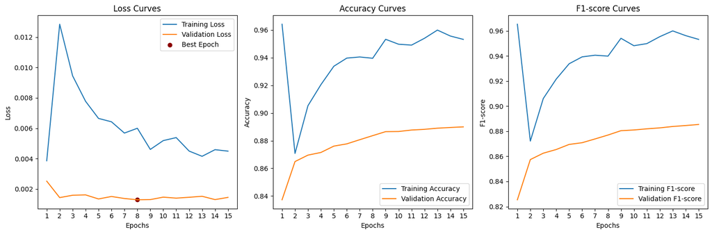

```python
# function to plot curves

def plot_curves(stats):
    # Extract data from the dictionary
    training_loss = stats['training_loss']
    training_accuracy = stats['training_accuracy']
    training_f1 = stats['training_f1']

    validation_loss = stats['validation_loss']
    validation_accuracy = stats['validation_accuracy']
    validation_f1 = stats['validation_f1']

    best_epoch = stats['best_epoch']
    loss_on_best_epoch = stats['loss_on_best_epoch']

    epochs = range(1, len(training_loss) + 1)

    # Plotting loss curve
    plt.figure(figsize=(15, 5))

    plt.subplot(1, 3, 1)
    plt.plot(epochs, training_loss, label='Training Loss')
    plt.plot(epochs, validation_loss, label='Validation Loss')
    plt.scatter(best_epoch, loss_on_best_epoch, color='darkred', marker='o', label='Best Epoch')
    plt.title('Loss Curves')
    plt.xlabel('Epochs')
    plt.ylabel('Loss')
    plt.xticks(epochs)  # Ensure x-axis ticks are integers
    plt.legend()

    # Plotting accuracy curve
    plt.subplot(1, 3, 2)
    plt.plot(epochs, training_accuracy, label='Training Accuracy')
    plt.plot(epochs, validation_accuracy, label='Validation Accuracy')
    plt.title('Accuracy Curves')
    plt.xlabel('Epochs')
    plt.ylabel('Accuracy')
    plt.xticks(epochs)  # Ensure x-axis ticks are integers
    plt.legend()

    # Plotting F1-score curve
    plt.subplot(1, 3, 3)
    plt.plot(epochs, training_f1, label='Training F1-score')
    plt.plot(epochs, validation_f1, label='Validation F1-score')
    plt.title('F1-score Curves')
    plt.xlabel('Epochs')
    plt.ylabel('F1-score')
    plt.xticks(epochs)  # Ensure x-axis ticks are integers
    plt.legend()

    plt.tight_layout()
    plt.show()

# displaying curves
plot_curves(training_stats)
```

```python
# saving model and checkpoint
MODEL_SAVE_PATH = save_model(model, "mobilenet_V3_large")
CHKPT_SAVE_PATH = save_checkpoint(optimizer,
                                  criterion,
                                  epoch = training_stats["best_epoch"]-1,
                                  device_trained_on = device,
                                  hidden_layers = (HIDDEN_LAYER1, HIDDEN_LAYER2),
                                  output_layer = NUM_CLASSES,
                                  classes = CLASSES,
                                  class_to_idx = CLASS_TO_IDX,
                                  checkpoint_name = "checkpoint")

# loading model and checkpoint
CHKPT_DICT = load_checkpoint(CHKPT_SAVE_PATH)
new_model = load_model(MODEL_SAVE_PATH,
                       hidden_layers = CHKPT_DICT["hidden_layers"],
                       output_layer = CHKPT_DICT["output_layer"],
                       device_trained_on = CHKPT_DICT["device_trained_on"],
                       device = torch.device("cpu"))
```

```
[INFO] mobilenet_V3_large saved to ./mobilenet_V3_large.pth
[INFO] The general checkpoint has been saved to: ./checkpoint.pth
```

```python
def predict_and_plot_topk(model: nn.Module,
                          img_transform: transforms.Compose,
                          class_list: list,
                          image_path: str,
                          device: torch.device,
                          topk: int = 5):

    # Load and preprocess the image
    image = Image.open(image_path).convert("RGB")
    input_tensor = img_transform(image)
    input_batch = input_tensor.unsqueeze(0).to(device)

    # Moving model to device and switching to eval mode
    model.to(device)
    model.eval()

    # Make predictions
    with torch.inference_mode():
        output = model(input_batch)

    # Convert the output to probabilities using softmax
    probabilities = torch.nn.functional.softmax(output[0], dim=0)

    # Get the top-k class indices and probabilities
    topk_probs, topk_indices = torch.topk(probabilities, topk)
    topk_probs_np = topk_probs.numpy(force=True)

    topk_indices_np = topk_indices.numpy(force=True)
    print("Prnting topk indices")
    print(topk_indices)
    print(topk_probs)

    # Convert tensor to numpy array for plotting
    probs_np = probabilities.numpy(force=True)
    print("Print probs_np")
    print(probs_np)

    # Create a horizontal bar graph
    plt.figure(figsize=(10, 6))

    # Plot the image
    plt.subplot(2, 1, 1)
    plt.imshow(image)
    plt.title('Input Image')
    plt.axis('off')

    # Plot the top-k classes
    plt.subplot(2, 1, 2)
    plt.barh([class_list[i] for i in topk_indices_np], topk_probs_np, color='blue')
    plt.xlabel('Predicted Probability')
    plt.title(f'Top-{topk} Predicted Classes')

    plt.tight_layout()
    plt.show()

    return topk_probs, topk_indices

# downloading a sample image
!wget https://i.ytimg.com/vi/tXjHb5QmDV0/maxresdefault.jpg -O /content/image.jpg      # provide link to any .jpg image here

# Example usage
# Assuming you have a PyTorch model 'new_model', a list of class names extracted using dataset_name.classes, and an image file path
topk_probs, topk_indice= predict_and_plot_topk(new_model,
                      mobilenet_transforms,
                      CLASSES,
                      "/content/flowers/test/10/image_07090.jpg",
                      device,
                      topk=2)
print(CLASS_TO_IDX)
```

[output not shown]

```python
print(CLASS_TO_IDX)
```

```
{'1': 0, '10': 1, '100': 2, '101': 3, '102': 4, '11': 5, '12': 6, '13': 7, '14': 8, '15': 9, '16': 10, '17': 11, '18': 12, '19': 13, '2': 14, '20': 15, '21': 16, '22': 17, '23': 18, '24': 19, '25': 20, '26': 21, '27': 22, '28': 23, '29': 24, '3': 25, '30': 26, '31': 27, '32': 28, '33': 29, '34': 30,…
```

```python
max_index= torch.argmax(topk_probs)
print(max_index)
pred_indices= topk_indice[max_index]
pred_indices= int(pred_indices.numpy(force=True))
print(pred_indices)
```

```
tensor(0, device='cuda:0')
1
```

```python
def get_class_name(pred_indices, dict_dir):
    key = [key for key, val in CLASS_TO_IDX.items() if val == pred_indices]
    with open(dict_dir, "r") as f:
         cat_to_name = json.load(f)
    print("Name of flower is:  ")
    class_name= cat_to_name[key[0]]
    return class_name.title()
```

```python
get_class_name(pred_indices, "/content/cat_to_name.json")
```

```
Name of flower is:
```

```
'Globe Thistle'
```

```python
import shutil

# Define the notebook file and zip file name
notebook_filename = "/content/drive/MyDrive/Colab Notebooks/AIPND_image_classifier_project.ipynb"
zip_filename = "Image_classifier_project.zip"

# Zip the notebook file
shutil.make_archive("Image_classifier_project", 'zip', root_dir=".", base_dir=notebook_filename)

# Download the ZIP file
from google.colab import files
files.download(zip_filename)
```

```python
!ls
```

```
Image_classifier_project.zip  sample_data
```

```python
from google.colab import drive
drive.mount('/content/drive')
```